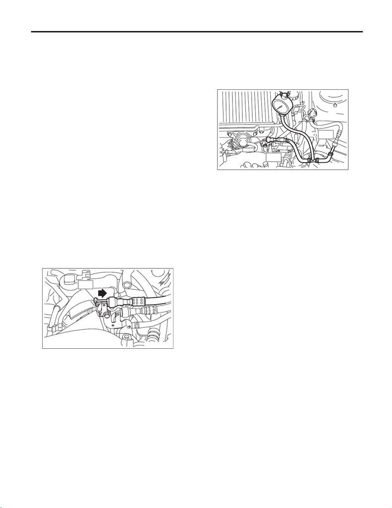

Fuel Pressure

MECHANICAL

7. Fuel Pressure

A: INSPECTION

CAUTION:

• Before removing the fuel pressure gauge, re-

lease the fuel pressure.

• Be careful not to spill fuel.

• Catch the fuel from hoses using a container

or cloth.

1) Release the fuel pressure. <Ref. to FU(STI)-64,

RELEASING OF FUEL PRESSURE, PROCE-

DURE, Fuel.>

2) Open the fuel filler lid and remove the fuel filler

cap.

NOTE:

This operation is required to release the inner pres-

sure of the fuel tank.

3) Disconnect the fuel delivery hose from the fuel

delivery pipe, and connect the fuel pressure gauge.

CAUTION:

• Be careful not to spill fuel.

• Catch the fuel from hoses using a container

or cloth.

(1) Attach ST to the fuel delivery pipe and push

ST in the direction of arrow mark to disconnect

the quick connector of the fuel delivery hose.

ST 42099AE000 QUICK CONNECTOR RE-

LEASE

(2) Connect the fuel pressure gauge with ST1

and ST2.

NOTE:

ST1 is a SUBARU genuine part.

ST1 42075AG690 FUEL HOSE

ST2 18471AA000 FUEL PIPE ADAPTER

4) Start the engine.

5) Check the fuel pressure while disconnecting

pressure regulator vacuum hose from intake mani-

fold.

NOTE:

• The fuel pressure gauge registers 10 to 20 kPa

(0.1 to 0.2 kg/cm

2

, 1 to 3 psi) higher than standard

values during high-altitude operations.

• If the fuel pressure is out of specification, check

or replace the fuel pump, fuel line, pressure regula-

tor & damper assembly, and pressure regulator

vacuum hose.

Fuel pressure:

Standard

284 — 314 kPa (2.9 — 3.2 kg/cm

2

, 41 — 46

psi)

6) After connecting the vacuum hose to the pres-

sure regulator, check the fuel pressure again.

NOTE:

• The fuel pressure gauge registers 10 to 20 kPa

(0.1 to 0.2 kg/cm

2

, 1 to 3 psi) higher than standard

values during high-altitude operations.

• If the fuel pressure is out of specification, check

or replace the fuel pump, fuel line, pressure regula-

tor & damper assembly, and pressure regulator

vacuum hose.

Fuel pressure:

Standard

230 — 260 kPa (2.4 — 2.7 kg/cm

2

, 33 — 38

psi)

7) After inspection, install the related parts in the

reverse order of removal.

ST

ST2

ST1